# Classifying AML vs ALL Leukaemia from Gene Expression (Golub et al. 1999)

H.A.K Chamikara Madushanka

17 November 2026

# 0. Setup

Run this block once (it is not evaluated when knitting).

```r
if (!requireNamespace("BiocManager", quietly = TRUE)) install.packages("BiocManager")
BiocManager::install(c("golubEsets", "Biobase", "limma"))
install.packages(c("tidyverse", "caret", "e1071", "pheatmap"))
```

```r
library(golubEsets)   # Golub leukaemia data
library(Biobase)      # ExpressionSet accessors
library(limma)        # differential expression
library(caret)        # model training / evaluation
library(e1071)        # SVM backend
library(pheatmap)     # heatmaps
library(tidyverse)    # data wrangling + ggplot2
```

# 1. Data import

Golub_Train (38 samples) and Golub_Test (34 samples) are the original training/independent test split from the paper. Golub_Merge holds all 72.

```r
data(Golub_Merge)
data(Golub_Train)
data(Golub_Test)
eset  <- Golub_Merge
expr  <- exprs(eset)        # genes x samples (Affymetrix intensities)
pheno <- pData(eset)

cat("Genes (probe sets):", nrow(expr), "\nSamples:", ncol(expr), "\n")
```

```
## Genes (probe sets): 7129
## Samples: 72
```

```r
head(pheno[, c("ALL.AML", "T.B.cell", "Gender", "Source")], 5)
```

```
##    ALL.AML T.B.cell Gender Source
## 39     ALL   B-cell      F   DFCI
## 40     ALL   B-cell      F   DFCI
## 42     ALL   B-cell      F   DFCI
## 47     ALL   B-cell      M   DFCI
## 48     ALL   B-cell      F   DFCI
```

```r
# Class label: ALL = acute lymphoblastic leukaemia, AML = acute myeloid
class <- factor(pheno$ALL.AML, levels = c("ALL", "AML"))
table(class)
```

```
## class
## ALL AML
##  47  25
```

```r
# Match samples to the original Golub training set by sample name
train_names <- sampleNames(Golub_Train)
train_idx <- which(colnames(expr) %in% train_names)
test_idx  <- setdiff(seq_len(ncol(expr)), train_idx)

length(train_idx)
```

```
## [1] 38
```

```r
print(table(class[train_idx])); print(table(class[test_idx]))
```

```
##
## ALL AML
##  27  11
```

```
##
## ALL AML
##  20  14
```

# 2. Quality control and preprocessing

```r
cat("Missing values:", sum(is.na(expr)), "\n")
```

```
## Missing values: 0
```

```r
summary(as.vector(expr))
```

```
##     Min.  1st Qu.   Median     Mean  3rd Qu.     Max.
## -28400.0    -21.0    120.0    619.8    440.0  71369.0
```

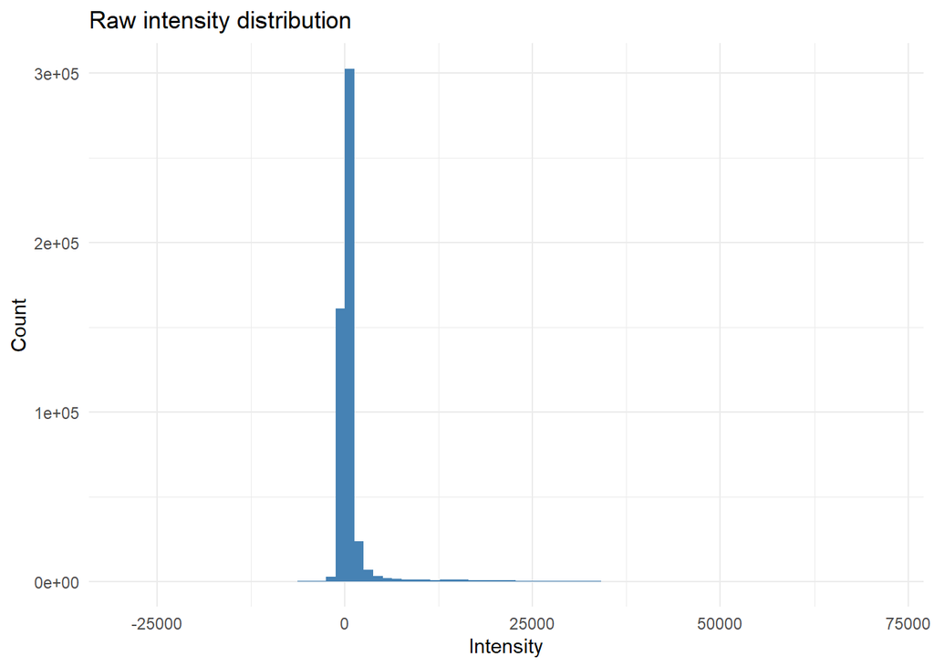

```r
# Raw intensities are heavily skewed and include negatives -> motivates preprocessing
qc_raw <- data.frame(value = as.vector(expr))
p_raw <- ggplot(qc_raw, aes(value)) +
  geom_histogram(bins = 80, fill = "steelblue") +
  labs(title = "Raw intensity distribution", x = "Intensity", y = "Count") +
  theme_minimal()
p_raw
```

```r
ggsave("../figures/raw_intensity_hist.png", p_raw, width = 7, height = 5, dpi = 150)
```

Preprocessing follows the standard Golub/Dudoit pipeline: 1. Floor at 100 and ceiling at 16,000 (values outside are unreliable). 2. Keep genes with max/min > 5 and max - min > 500 (removes uninformative genes). 3. log2 transform to stabilise variance.

```r
expr_p <- expr
expr_p[expr_p < 100]   <- 100
expr_p[expr_p > 16000] <- 16000

mx <- apply(expr_p, 1, max)
mn <- apply(expr_p, 1, min)
keep <- (mx / mn > 5) & (mx - mn > 500)
cat("Genes kept after filtering:", sum(keep), "of", length(keep), "\n")
```

```
## Genes kept after filtering: 3571 of 7129
```

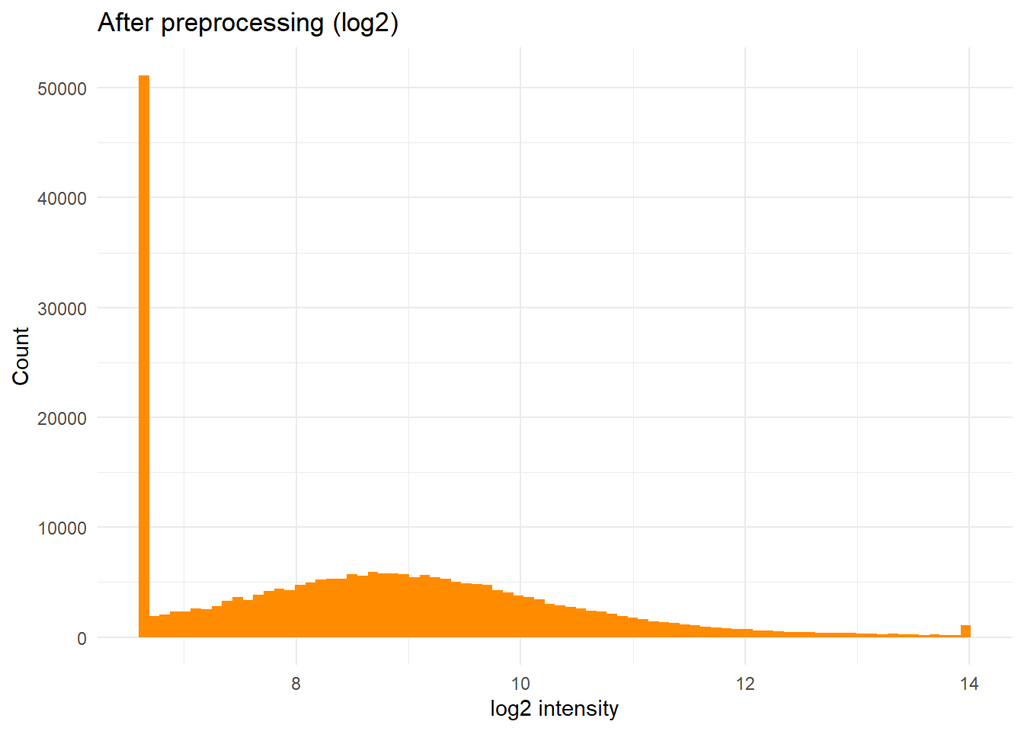

```r
expr_f <- log2(expr_p[keep, ])

# Gene annotation (fall back to probe IDs if the featureData is empty)
fd <- tryCatch(fData(eset)[keep, , drop = FALSE], error = function(e) NULL)
desc_col <- if (!is.null(fd)) grep("Description", colnames(fd), value = TRUE)[1] else NA
gene_desc <- if (!is.na(desc_col)) as.character(fd[[desc_col]]) else rownames(expr_f)
names(gene_desc) <- rownames(expr_f)

p_clean <- ggplot(data.frame(value = as.vector(expr_f)), aes(value)) +
  geom_histogram(bins = 80, fill = "darkorange") +
  labs(title = "After preprocessing (log2)", x = "log2 intensity", y = "Count") +
  theme_minimal()
p_clean
```

```r
ggsave("../figures/clean_intensity_hist.png", p_clean, width = 7, height = 5, dpi = 150)
```

# 3. Exploratory data analysis

## 3.1 Sample distributions

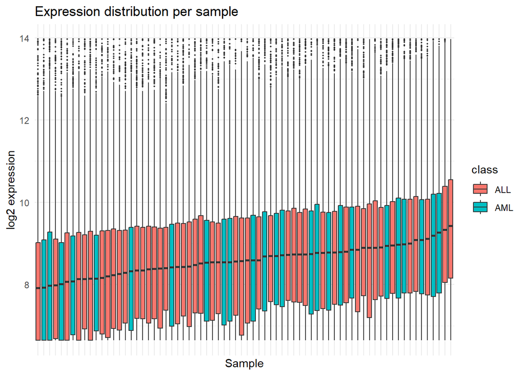

```r
long <- as.data.frame(t(expr_f)) |>
  mutate(sample = colnames(expr_f), class = class) |>
  pivot_longer(-c(sample, class), names_to = "gene", values_to = "log2expr")

p_box <- ggplot(long, aes(x = reorder(sample, log2expr, median), y = log2expr, fill = class)) +
  geom_boxplot(outlier.size = 0.3) +
  labs(title = "Expression distribution per sample", x = "Sample", y = "log2 expression") +
  theme_minimal() + theme(axis.text.x = element_blank())
p_box
```

```r
ggsave("../figures/sample_boxplot.png", p_box, width = 9, height = 5, dpi = 150)
```

## 3.2 PCA

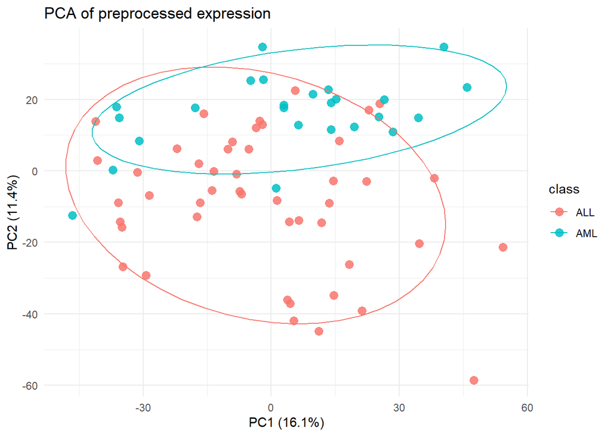

```r
pca <- prcomp(t(expr_f), scale. = TRUE)
var_exp <- round(100 * summary(pca)$importance[2, 1:2], 1)

pca_df <- data.frame(PC1 = pca$x[, 1], PC2 = pca$x[, 2], class = class)
p_pca <- ggplot(pca_df, aes(PC1, PC2, colour = class)) +
  geom_point(size = 3, alpha = 0.85) +
  stat_ellipse(level = 0.9) +
  labs(title = "PCA of preprocessed expression",
       x = paste0("PC1 (", var_exp[1], "%)"), y = paste0("PC2 (", var_exp[2], "%)")) +
  theme_minimal()
p_pca
```

```r
ggsave("../figures/pca.png", p_pca, width = 7, height = 5, dpi = 150)
```

## 3.3 Hierarchical clustering

```r
d  <- dist(t(expr_f))
hc <- hclust(d, method = "ward.D2")
png("../figures/dendrogram.png", width = 1200, height = 600, res = 120)
plot(hc, labels = as.character(class), cex = 0.6,
     main = "Hierarchical clustering of samples (Ward, Euclidean)")
dev.off()
```

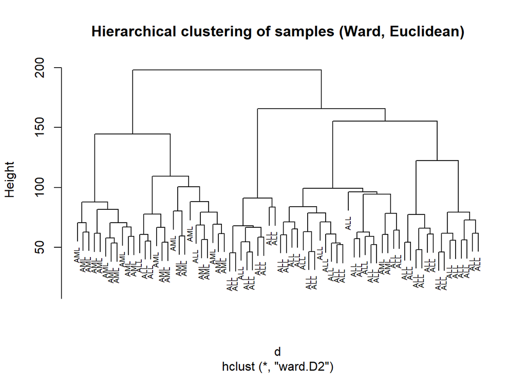

```r
plot(hc, labels = as.character(class), cex = 0.6,
     main = "Hierarchical clustering of samples (Ward, Euclidean)")
```

```r
# How well does a 2-cluster cut recover the true classes?
table(cluster = cutree(hc, 2), class = class)
```

```
##        class
## cluster ALL AML
##       1  43   2
##       2   4  23
```

# 4. Differential expression (limma)

To avoid information leakage into the classifier later, differential expression for *feature selection* uses the **training set only**. A second analysis on all 72 samples is used for biological interpretation.

```r
design_all <- model.matrix(~ class)
fit_all <- eBayes(lmFit(expr_f, design_all))
tt_all <- topTable(fit_all, coef = "classAML", number = Inf, adjust.method = "BH") |>
  rownames_to_column("probe") |>
  mutate(description = gene_desc[probe])

cat("Significant genes (adj.P < 0.05, |logFC| > 1):",
    sum(tt_all$adj.P.Val < 0.05 & abs(tt_all$logFC) > 1), "\n")
```

```
## Significant genes (adj.P < 0.05, |logFC| > 1): 276
```

```r
head(tt_all[, c("probe", "description", "logFC", "adj.P.Val")], 15)
```

```
##             probe    description     logFC    adj.P.Val
## 1       M84526_at      M84526_at  4.725821 5.633634e-21
## 2       M27891_at      M27891_at  4.807517 7.735118e-20
## 3       U46499_at      U46499_at  3.190413 4.494284e-19
## 4       M23197_at      M23197_at  2.171193 2.187360e-17
## 5       X95735_at      X95735_at  3.289352 1.228403e-15
## 6       D88422_at      D88422_at  3.319930 1.864241e-15
## 7       M31523_at      M31523_at -2.073777 8.943026e-15
## 8       M11722_at      M11722_at -3.783291 4.662083e-14
## 9     L09209_s_at    L09209_s_at  2.568568 1.249315e-12
## 10      J05243_at      J05243_at -1.994976 4.402096e-12
## 11    M83652_s_at    M83652_s_at  2.594675 4.567468e-12
## 12      M63138_at      M63138_at  1.652318 6.098021e-12
## 13      M19507_at      M19507_at  3.978843 8.631207e-12
## 14 M96326_rna1_at M96326_rna1_at  3.160379 8.940734e-12
## 15      M92287_at      M92287_at -2.055707 2.618708e-11
```

```r
write_csv(tt_all, "../results/limma_AML_vs_ALL_all_samples.csv")
```

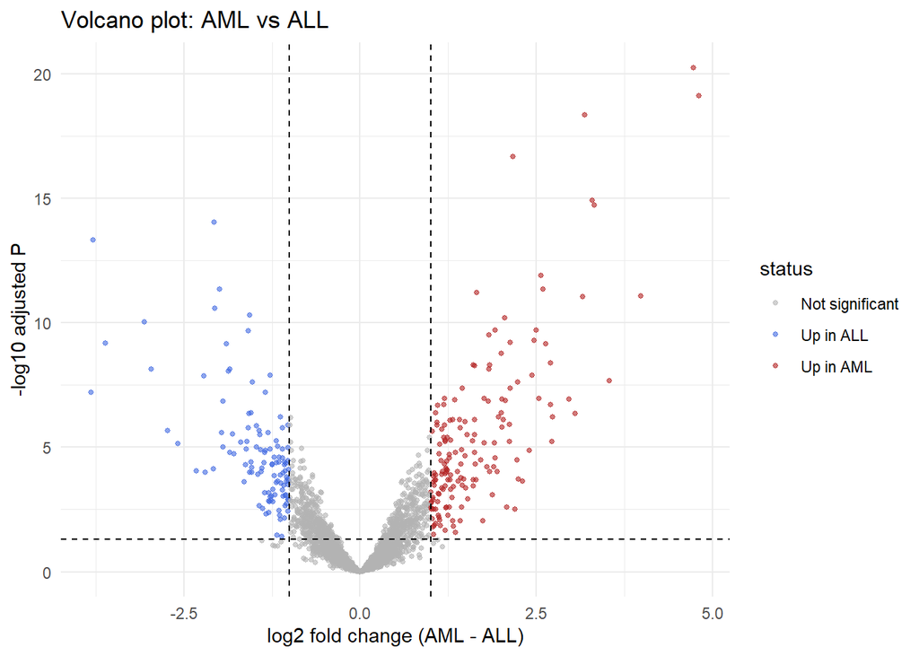

```r
tt_all <- tt_all |>
  mutate(status = case_when(adj.P.Val < 0.05 & logFC >  1 ~ "Up in AML",
                            adj.P.Val < 0.05 & logFC < -1 ~ "Up in ALL",
                            TRUE ~ "Not significant"))
p_vol <- ggplot(tt_all, aes(logFC, -log10(adj.P.Val), colour = status)) +
  geom_point(alpha = 0.6, size = 1) +
  scale_colour_manual(values = c("Up in AML" = "firebrick", "Up in ALL" = "royalblue",
                                 "Not significant" = "grey70")) +
  geom_vline(xintercept = c(-1, 1), linetype = "dashed") +
  geom_hline(yintercept = -log10(0.05), linetype = "dashed") +
  labs(title = "Volcano plot: AML vs ALL", x = "log2 fold change (AML - ALL)",
       y = "-log10 adjusted P") +
  theme_minimal()
p_vol
```

```r
ggsave("../figures/volcano.png", p_vol, width = 7, height = 5, dpi = 150)
```

```r
top50 <- tt_all$probe[1:50]
ann <- data.frame(class = class, row.names = colnames(expr_f))
pheatmap(expr_f[top50, ], scale = "row", annotation_col = ann,
         show_rownames = FALSE, show_colnames = FALSE,
         main = "Top 50 differentially expressed genes",
         filename = "../figures/heatmap_top50.png", width = 8, height = 7)
pheatmap(expr_f[top50, ], scale = "row", annotation_col = ann,
         show_rownames = FALSE, show_colnames = FALSE,
         main = "Top 50 differentially expressed genes")
```

[output not shown]

# 5. Predictive model: SVM

Pipeline (no leakage): limma on the training samples only, select the top *k* genes, train a linear SVM with repeated 5-fold cross-validation, then evaluate once on the independent test set.

```r
x_train <- expr_f[, train_idx]; y_train <- class[train_idx]
x_test  <- expr_f[, test_idx];  y_test  <- class[test_idx]

# Feature selection on training data only
fit_tr <- eBayes(lmFit(x_train, model.matrix(~ y_train)))
rank_tr <- topTable(fit_tr, coef = 2, number = Inf, sort.by = "P")
top_genes <- function(k) rownames(rank_tr)[1:k]

ctrl <- trainControl(method = "repeatedcv", number = 5, repeats = 5,
                     classProbs = TRUE, summaryFunction = twoClassSummary)

fit_svm <- function(k) {
  g <- top_genes(k)
  train(x = t(x_train[g, ]), y = y_train, method = "svmLinear2",
        trControl = ctrl, metric = "ROC",
        preProcess = c("center", "scale"),
        tuneGrid = data.frame(cost = c(0.01, 0.1, 1, 10)))
}

model <- fit_svm(50)
model
```

```
## Support Vector Machines with Linear Kernel
##
## 38 samples
## 50 predictors
##  2 classes: 'ALL', 'AML'
##
## Pre-processing: centered (50), scaled (50)
## Resampling: Cross-Validated (5 fold, repeated 5 times)
## Summary of sample sizes: 31, 30, 30, 30, 31, 30, ...
## Resampling results across tuning parameters:
##
##   cost   ROC  Sens  Spec
##    0.01  1    1     1
##    0.10  1    1     1
##    1.00  1    1     1
##   10.00  1    1     1
##
## ROC was used to select the optimal model using the largest value.
## The final value used for the model was cost = 0.01.
```

```r
g50 <- top_genes(50)
pred <- predict(model, t(x_test[g50, ]))
cm <- confusionMatrix(pred, y_test, positive = "AML")
cm
```

```
## Confusion Matrix and Statistics
##
##           Reference
## Prediction ALL AML
##        ALL  20   1
##        AML   0  13
##
##                Accuracy : 0.9706
##                  95% CI : (0.8467, 0.9993)
##     No Information Rate : 0.5882
##     P-Value [Acc > NIR] : 3.624e-07
##
##                   Kappa : 0.9386
##
##  Mcnemar's Test P-Value : 1
##
##             Sensitivity : 0.9286
##             Specificity : 1.0000
##          Pos Pred Value : 1.0000
##          Neg Pred Value : 0.9524
##              Prevalence : 0.4118
##          Detection Rate : 0.3824
##    Detection Prevalence : 0.3824
##       Balanced Accuracy : 0.9643
##
##        'Positive' Class : AML
##
```

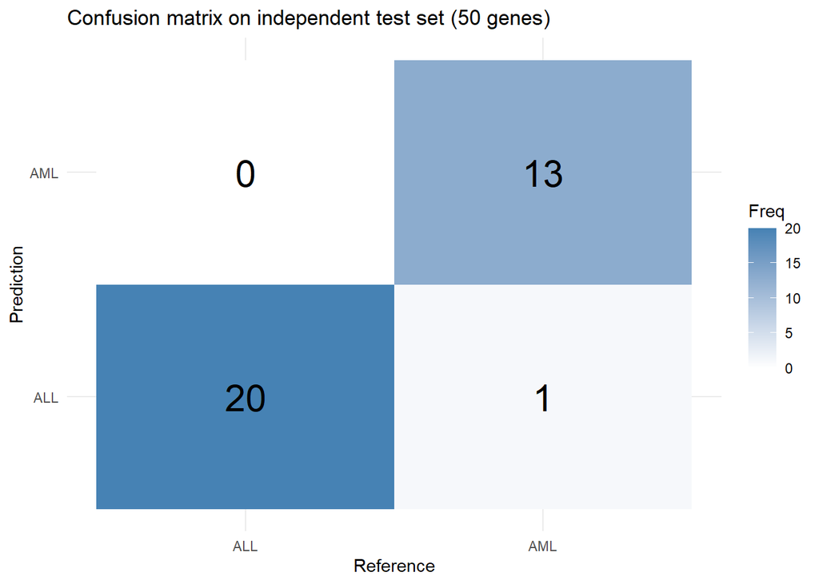

```r
cm_df <- as.data.frame(cm$table)
p_cm <- ggplot(cm_df, aes(Reference, Prediction, fill = Freq)) +
  geom_tile() + geom_text(aes(label = Freq), size = 8) +
  scale_fill_gradient(low = "white", high = "steelblue") +
  labs(title = "Confusion matrix on independent test set (50 genes)") +
  theme_minimal()
p_cm
```

```r
ggsave("../figures/confusion_matrix.png", p_cm, width = 6, height = 5, dpi = 150)
```

## 5.1 Sensitivity to number of genes

```r
ks <- c(2, 5, 10, 25, 50, 100, 250)
sweep <- map_dfr(ks, function(k) {
  m <- fit_svm(k)
  p <- predict(m, t(x_test[top_genes(k), ]))
  tibble(k = k,
         cv_auc = max(m$results$ROC),
         test_acc = mean(p == y_test))
})
sweep
```

```
## # A tibble: 7 × 3
##       k cv_auc test_acc
##   <dbl>  <dbl>    <dbl>
## 1     2  0.994    0.912
## 2     5  1        0.941
## 3    10  1        0.971
## 4    25  1        0.971
## 5    50  1        0.971
## 6   100  1        0.941
## 7   250  1        0.912
```

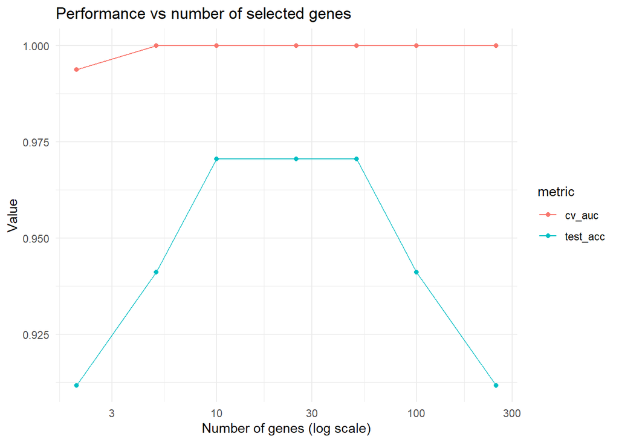

```r
p_k <- sweep |>
  pivot_longer(-k, names_to = "metric", values_to = "value") |>
  ggplot(aes(k, value, colour = metric)) +
  geom_line() + geom_point() + scale_x_log10() +
  labs(title = "Performance vs number of selected genes",
       x = "Number of genes (log scale)", y = "Value") +
  theme_minimal()
p_k
```

```r
ggsave("../figures/k_sweep.png", p_k, width = 7, height = 5, dpi = 150)
write_csv(sweep, "../results/svm_k_sweep.csv")
```

# 6. Top marker genes for interpretation

```r
markers <- tt_all |>
  slice_head(n = 10) |>
  select(probe, description, logFC, adj.P.Val)
markers
```

```
##          probe description     logFC    adj.P.Val
## 1    M84526_at   M84526_at  4.725821 5.633634e-21
## 2    M27891_at   M27891_at  4.807517 7.735118e-20
## 3    U46499_at   U46499_at  3.190413 4.494284e-19
## 4    M23197_at   M23197_at  2.171193 2.187360e-17
## 5    X95735_at   X95735_at  3.289352 1.228403e-15
## 6    D88422_at   D88422_at  3.319930 1.864241e-15
## 7    M31523_at   M31523_at -2.073777 8.943026e-15
## 8    M11722_at   M11722_at -3.783291 4.662083e-14
## 9  L09209_s_at L09209_s_at  2.568568 1.249315e-12
## 10   J05243_at   J05243_at -1.994976 4.402096e-12
```

```r
write_csv(markers, "../results/top10_markers.csv")
```

Look up each gene in GeneCards/UniProt/PubMed and note its known role in leukaemia for the Discussion section of the report.